# Risk Factor Analysis

## Outcome Variable

**Outcome Variable:** y_rate_len

## Predictor Variables

**Intervention Variable:** predfeed6

**Adjustment Set:**

unadjusted

## Stratifying Variables

The analysis was stratified on these variable(s):

- agecat
- studyid
- country

## Data Summary

| agecat | studyid | country | predfeed6 | n_cell | n |
| --- | --- | --- | --- | --- | --- |
| 0-3 months | EE | PAKISTAN | 1 | 33 | 37 |
| 0-3 months | EE | PAKISTAN | 0 | 4 | 37 |
| 0-3 months | GMS-Nepal | NEPAL | 1 | 368 | 501 |
| 0-3 months | GMS-Nepal | NEPAL | 0 | 133 | 501 |
| 0-3 months | MAL-ED | BANGLADESH | 1 | 82 | 227 |
| 0-3 months | MAL-ED | BANGLADESH | 0 | 145 | 227 |
| 0-3 months | MAL-ED | BRAZIL | 1 | 21 | 163 |
| 0-3 months | MAL-ED | BRAZIL | 0 | 142 | 163 |
| 0-3 months | MAL-ED | INDIA | 1 | 8 | 167 |
| 0-3 months | MAL-ED | INDIA | 0 | 159 | 167 |
| 0-3 months | MAL-ED | NEPAL | 1 | 11 | 145 |
| 0-3 months | MAL-ED | NEPAL | 0 | 134 | 145 |
| 0-3 months | MAL-ED | PERU | 1 | 85 | 254 |
| 0-3 months | MAL-ED | PERU | 0 | 169 | 254 |
| 0-3 months | MAL-ED | SOUTH AFRICA | 1 | 2 | 186 |
| 0-3 months | MAL-ED | SOUTH AFRICA | 0 | 184 | 186 |
| 0-3 months | MAL-ED | TANZANIA, UNITED REPUBLIC OF | 1 | 0 | 211 |
| 0-3 months | MAL-ED | TANZANIA, UNITED REPUBLIC OF | 0 | 211 | 211 |
| 3-6 months | EE | PAKISTAN | 1 | 34 | 38 |
| 3-6 months | EE | PAKISTAN | 0 | 4 | 38 |
| 3-6 months | GMS-Nepal | NEPAL | 1 | 338 | 464 |
| 3-6 months | GMS-Nepal | NEPAL | 0 | 126 | 464 |
| 3-6 months | MAL-ED | BANGLADESH | 1 | 80 | 222 |
| 3-6 months | MAL-ED | BANGLADESH | 0 | 142 | 222 |
| 3-6 months | MAL-ED | BRAZIL | 1 | 30 | 208 |
| 3-6 months | MAL-ED | BRAZIL | 0 | 178 | 208 |
| 3-6 months | MAL-ED | INDIA | 1 | 11 | 213 |
| 3-6 months | MAL-ED | INDIA | 0 | 202 | 213 |
| 3-6 months | MAL-ED | NEPAL | 1 | 11 | 222 |
| 3-6 months | MAL-ED | NEPAL | 0 | 211 | 222 |

[output cut: 134 more lines]

The following strata were considered:

- agecat: 0-3 months, studyid: EE, country: PAKISTAN
- agecat: 0-3 months, studyid: GMS-Nepal, country: NEPAL
- agecat: 0-3 months, studyid: MAL-ED, country: BANGLADESH
- agecat: 0-3 months, studyid: MAL-ED, country: BRAZIL
- agecat: 0-3 months, studyid: MAL-ED, country: INDIA
- agecat: 0-3 months, studyid: MAL-ED, country: NEPAL
- agecat: 0-3 months, studyid: MAL-ED, country: PERU
- agecat: 0-3 months, studyid: MAL-ED, country: SOUTH AFRICA
- agecat: 0-3 months, studyid: MAL-ED, country: TANZANIA, UNITED REPUBLIC OF
- agecat: 12-15 months, studyid: EE, country: PAKISTAN
- agecat: 12-15 months, studyid: GMS-Nepal, country: NEPAL
- agecat: 12-15 months, studyid: LCNI-5, country: MALAWI
- agecat: 12-15 months, studyid: MAL-ED, country: BANGLADESH
- agecat: 12-15 months, studyid: MAL-ED, country: BRAZIL
- agecat: 12-15 months, studyid: MAL-ED, country: INDIA
- agecat: 12-15 months, studyid: MAL-ED, country: NEPAL
- agecat: 12-15 months, studyid: MAL-ED, country: PERU
- agecat: 12-15 months, studyid: MAL-ED, country: SOUTH AFRICA
- agecat: 12-15 months, studyid: MAL-ED, country: TANZANIA, UNITED REPUBLIC OF
- agecat: 12-15 months, studyid: SAS-FoodSuppl, country: INDIA
- agecat: 15-18 months, studyid: EE, country: PAKISTAN
- agecat: 15-18 months, studyid: GMS-Nepal, country: NEPAL
- agecat: 15-18 months, studyid: LCNI-5, country: MALAWI
- agecat: 15-18 months, studyid: MAL-ED, country: BANGLADESH
- agecat: 15-18 months, studyid: MAL-ED, country: BRAZIL
- agecat: 15-18 months, studyid: MAL-ED, country: INDIA
- agecat: 15-18 months, studyid: MAL-ED, country: NEPAL
- agecat: 15-18 months, studyid: MAL-ED, country: PERU
- agecat: 15-18 months, studyid: MAL-ED, country: SOUTH AFRICA
- agecat: 15-18 months, studyid: MAL-ED, country: TANZANIA, UNITED REPUBLIC OF
- agecat: 15-18 months, studyid: SAS-FoodSuppl, country: INDIA
- agecat: 18-21 months, studyid: EE, country: PAKISTAN
- agecat: 18-21 months, studyid: GMS-Nepal, country: NEPAL
- agecat: 18-21 months, studyid: LCNI-5, country: MALAWI
- agecat: 18-21 months, studyid: MAL-ED, country: BANGLADESH
- agecat: 18-21 months, studyid: MAL-ED, country: BRAZIL
- agecat: 18-21 months, studyid: MAL-ED, country: INDIA
- agecat: 18-21 months, studyid: MAL-ED, country: NEPAL
- agecat: 18-21 months, studyid: MAL-ED, country: PERU
- agecat: 18-21 months, studyid: MAL-ED, country: SOUTH AFRICA
- agecat: 18-21 months, studyid: MAL-ED, country: TANZANIA, UNITED REPUBLIC OF
- agecat: 21-24 months, studyid: EE, country: PAKISTAN
- agecat: 21-24 months, studyid: GMS-Nepal, country: NEPAL
- agecat: 21-24 months, studyid: LCNI-5, country: MALAWI
- agecat: 21-24 months, studyid: MAL-ED, country: BANGLADESH
- agecat: 21-24 months, studyid: MAL-ED, country: BRAZIL
- agecat: 21-24 months, studyid: MAL-ED, country: INDIA
- agecat: 21-24 months, studyid: MAL-ED, country: NEPAL
- agecat: 21-24 months, studyid: MAL-ED, country: PERU
- agecat: 21-24 months, studyid: MAL-ED, country: SOUTH AFRICA
- agecat: 21-24 months, studyid: MAL-ED, country: TANZANIA, UNITED REPUBLIC OF
- agecat: 3-6 months, studyid: EE, country: PAKISTAN
- agecat: 3-6 months, studyid: GMS-Nepal, country: NEPAL
- agecat: 3-6 months, studyid: MAL-ED, country: BANGLADESH
- agecat: 3-6 months, studyid: MAL-ED, country: BRAZIL
- agecat: 3-6 months, studyid: MAL-ED, country: INDIA
- agecat: 3-6 months, studyid: MAL-ED, country: NEPAL
- agecat: 3-6 months, studyid: MAL-ED, country: PERU
- agecat: 3-6 months, studyid: MAL-ED, country: SOUTH AFRICA
- agecat: 3-6 months, studyid: MAL-ED, country: TANZANIA, UNITED REPUBLIC OF
- agecat: 6-9 months, studyid: EE, country: PAKISTAN
- agecat: 6-9 months, studyid: GMS-Nepal, country: NEPAL
- agecat: 6-9 months, studyid: LCNI-5, country: MALAWI
- agecat: 6-9 months, studyid: MAL-ED, country: BANGLADESH
- agecat: 6-9 months, studyid: MAL-ED, country: BRAZIL
- agecat: 6-9 months, studyid: MAL-ED, country: INDIA
- agecat: 6-9 months, studyid: MAL-ED, country: NEPAL
- agecat: 6-9 months, studyid: MAL-ED, country: PERU
- agecat: 6-9 months, studyid: MAL-ED, country: SOUTH AFRICA
- agecat: 6-9 months, studyid: MAL-ED, country: TANZANIA, UNITED REPUBLIC OF
- agecat: 6-9 months, studyid: SAS-FoodSuppl, country: INDIA
- agecat: 9-12 months, studyid: EE, country: PAKISTAN
- agecat: 9-12 months, studyid: GMS-Nepal, country: NEPAL
- agecat: 9-12 months, studyid: LCNI-5, country: MALAWI
- agecat: 9-12 months, studyid: MAL-ED, country: BANGLADESH
- agecat: 9-12 months, studyid: MAL-ED, country: BRAZIL
- agecat: 9-12 months, studyid: MAL-ED, country: INDIA
- agecat: 9-12 months, studyid: MAL-ED, country: NEPAL
- agecat: 9-12 months, studyid: MAL-ED, country: PERU
- agecat: 9-12 months, studyid: MAL-ED, country: SOUTH AFRICA
- agecat: 9-12 months, studyid: MAL-ED, country: TANZANIA, UNITED REPUBLIC OF
- agecat: 9-12 months, studyid: SAS-FoodSuppl, country: INDIA

### Dropped Strata

Some strata were dropped due to rare outcomes:

- agecat: 0-3 months, studyid: EE, country: PAKISTAN
- agecat: 0-3 months, studyid: MAL-ED, country: SOUTH AFRICA
- agecat: 0-3 months, studyid: MAL-ED, country: TANZANIA, UNITED REPUBLIC OF
- agecat: 3-6 months, studyid: EE, country: PAKISTAN
- agecat: 3-6 months, studyid: MAL-ED, country: SOUTH AFRICA
- agecat: 3-6 months, studyid: MAL-ED, country: TANZANIA, UNITED REPUBLIC OF
- agecat: 6-9 months, studyid: MAL-ED, country: SOUTH AFRICA
- agecat: 6-9 months, studyid: MAL-ED, country: TANZANIA, UNITED REPUBLIC OF
- agecat: 6-9 months, studyid: SAS-FoodSuppl, country: INDIA
- agecat: 9-12 months, studyid: MAL-ED, country: SOUTH AFRICA
- agecat: 9-12 months, studyid: MAL-ED, country: TANZANIA, UNITED REPUBLIC OF
- agecat: 9-12 months, studyid: SAS-FoodSuppl, country: INDIA
- agecat: 12-15 months, studyid: LCNI-5, country: MALAWI
- agecat: 12-15 months, studyid: MAL-ED, country: SOUTH AFRICA
- agecat: 12-15 months, studyid: MAL-ED, country: TANZANIA, UNITED REPUBLIC OF
- agecat: 12-15 months, studyid: SAS-FoodSuppl, country: INDIA
- agecat: 15-18 months, studyid: LCNI-5, country: MALAWI
- agecat: 15-18 months, studyid: MAL-ED, country: SOUTH AFRICA
- agecat: 15-18 months, studyid: MAL-ED, country: TANZANIA, UNITED REPUBLIC OF
- agecat: 15-18 months, studyid: SAS-FoodSuppl, country: INDIA
- agecat: 18-21 months, studyid: MAL-ED, country: SOUTH AFRICA
- agecat: 18-21 months, studyid: MAL-ED, country: TANZANIA, UNITED REPUBLIC OF
- agecat: 21-24 months, studyid: EE, country: PAKISTAN
- agecat: 21-24 months, studyid: MAL-ED, country: SOUTH AFRICA
- agecat: 21-24 months, studyid: MAL-ED, country: TANZANIA, UNITED REPUBLIC OF

## Methods Detail

We’re interested in the causal parameters $E[Y_a]$ for all values of $a \in \mathcal{A}$. These parameters represent the mean outcome if, possibly contrary to fact, we intervened to set all units to have $A=a$. Under the randomization and positivity assumptions, these are identified by the statistical parameters $\psi_a=E_W[E_{Y|A,W}(Y|A=a,W)]$. In addition, we’re interested in the mean of $Y$, $E[Y]$ under no intervention (the observed mean). We will estimate these parameters by using SuperLearner to fit the relevant likelihood factors – $E_{Y|A,W}(Y|A=a,W)$ and $p(A=a|W)$, and then updating our likelihood fit using a joint TMLE.

For unadjusted analyses ($W=\{\}$), initial likelihoods were estimated using Lrnr_glm to estimate the simple $E(Y|A)$ and Lrnr_mean to estimate $p(A)$. For adjusted analyses, a small library containing Lrnr_glmnet, Lrnr_xgboost, and Lrnr_mean was used.

Having estimated these parameters, we will then use the delta method to estimate relative risks and attributable risks relative to a prespecified baseline level of $A$.

# Results Detail

## Results Plots

[figure not shown]

[figure not shown]

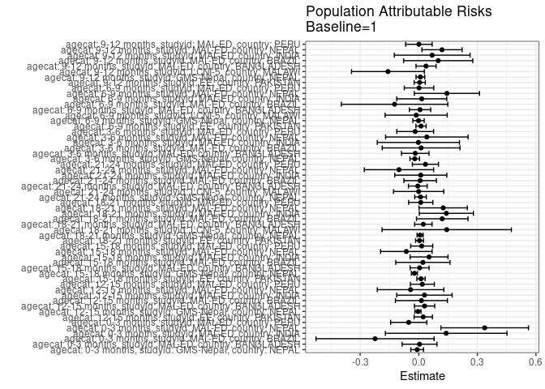

## Results Table

### Parameter: TSM

| agecat | studyid | country | intervention_level | baseline_level | estimate | ci_lower | ci_upper |
| --- | --- | --- | --- | --- | --- | --- | --- |
| 0-3 months | GMS-Nepal | NEPAL | 1 | NA | 3.6064403 | 3.5477991 | 3.6650815 |
| 0-3 months | GMS-Nepal | NEPAL | 0 | NA | 3.5756322 | 3.4678493 | 3.6834151 |
| 0-3 months | MAL-ED | BANGLADESH | 1 | NA | 3.3440623 | 3.2340741 | 3.4540505 |
| 0-3 months | MAL-ED | BANGLADESH | 0 | NA | 3.3506179 | 3.2645710 | 3.4366648 |
| 0-3 months | MAL-ED | BRAZIL | 1 | NA | 4.0424700 | 3.7159947 | 4.3689454 |
| 0-3 months | MAL-ED | BRAZIL | 0 | NA | 3.7859938 | 3.6688214 | 3.9031661 |
| 0-3 months | MAL-ED | INDIA | 1 | NA | 3.1975488 | 2.8853961 | 3.5097015 |
| 0-3 months | MAL-ED | INDIA | 0 | NA | 3.3449364 | 3.2480037 | 3.4418691 |
| 0-3 months | MAL-ED | NEPAL | 1 | NA | 3.2830490 | 3.0630022 | 3.5030958 |
| 0-3 months | MAL-ED | NEPAL | 0 | NA | 3.6482868 | 3.5480591 | 3.7485146 |
| 0-3 months | MAL-ED | PERU | 1 | NA | 3.1128016 | 2.9994763 | 3.2261269 |
| 0-3 months | MAL-ED | PERU | 0 | NA | 3.0356176 | 2.9552623 | 3.1159730 |
| 3-6 months | GMS-Nepal | NEPAL | 1 | NA | 1.7290586 | 1.6831784 | 1.7749389 |
| 3-6 months | GMS-Nepal | NEPAL | 0 | NA | 1.6539447 | 1.5764764 | 1.7314129 |
| 3-6 months | MAL-ED | BANGLADESH | 1 | NA | 1.9428303 | 1.8513078 | 2.0343529 |
| 3-6 months | MAL-ED | BANGLADESH | 0 | NA | 1.9146387 | 1.8534672 | 1.9758102 |
| 3-6 months | MAL-ED | BRAZIL | 1 | NA | 2.1341399 | 1.9175663 | 2.3507135 |
| 3-6 months | MAL-ED | BRAZIL | 0 | NA | 2.1480942 | 2.0630343 | 2.2331541 |
| 3-6 months | MAL-ED | INDIA | 1 | NA | 1.8862283 | 1.6753246 | 2.0971320 |
| 3-6 months | MAL-ED | INDIA | 0 | NA | 1.8842258 | 1.8153495 | 1.9531021 |
| 3-6 months | MAL-ED | NEPAL | 1 | NA | 1.9254229 | 1.7115830 | 2.1392627 |
| 3-6 months | MAL-ED | NEPAL | 0 | NA | 1.9690406 | 1.9088507 | 2.0292305 |
| 3-6 months | MAL-ED | PERU | 1 | NA | 2.0353824 | 1.9176661 | 2.1530987 |
| 3-6 months | MAL-ED | PERU | 0 | NA | 2.0077550 | 1.9274824 | 2.0880277 |
| 6-9 months | EE | PAKISTAN | 1 | NA | 1.1144238 | 0.9844462 | 1.2444013 |
| 6-9 months | EE | PAKISTAN | 0 | NA | 1.2194058 | 1.0438676 | 1.3949439 |
| 6-9 months | GMS-Nepal | NEPAL | 1 | NA | 1.3151777 | 1.2738648 | 1.3564907 |
| 6-9 months | GMS-Nepal | NEPAL | 0 | NA | 1.3106437 | 1.2035353 | 1.4177521 |
| 6-9 months | LCNI-5 | MALAWI | 1 | NA | 1.4504298 | 1.2732863 | 1.6275734 |
| 6-9 months | LCNI-5 | MALAWI | 0 | NA | 1.4347776 | 1.3694403 | 1.5001149 |

[output cut: 84 more lines]

### Parameter: E(Y)

| agecat | studyid | country | intervention_level | baseline_level | estimate | ci_lower | ci_upper |
| --- | --- | --- | --- | --- | --- | --- | --- |
| 0-3 months | GMS-Nepal | NEPAL | NA | NA | 3.5982617 | 3.5465367 | 3.6499867 |
| 0-3 months | MAL-ED | BANGLADESH | NA | NA | 3.3482498 | 3.2804281 | 3.4160715 |
| 0-3 months | MAL-ED | BRAZIL | NA | NA | 3.8190367 | 3.7078440 | 3.9302295 |
| 0-3 months | MAL-ED | INDIA | NA | NA | 3.3378760 | 3.2442606 | 3.4314913 |
| 0-3 months | MAL-ED | NEPAL | NA | NA | 3.6205791 | 3.5251464 | 3.7160118 |
| 0-3 months | MAL-ED | PERU | NA | NA | 3.0614469 | 2.9957442 | 3.1271496 |
| 3-6 months | GMS-Nepal | NEPAL | NA | NA | 1.7086613 | 1.6690533 | 1.7482692 |
| 3-6 months | MAL-ED | BANGLADESH | NA | NA | 1.9247979 | 1.8735932 | 1.9760025 |
| 3-6 months | MAL-ED | BRAZIL | NA | NA | 2.1460815 | 2.0668679 | 2.2252951 |
| 3-6 months | MAL-ED | INDIA | NA | NA | 1.8843292 | 1.8181080 | 1.9505504 |
| 3-6 months | MAL-ED | NEPAL | NA | NA | 1.9668794 | 1.9086855 | 2.0250732 |
| 3-6 months | MAL-ED | PERU | NA | NA | 2.0171026 | 1.9506965 | 2.0835088 |
| 6-9 months | EE | PAKISTAN | NA | NA | 1.1260884 | 1.0085133 | 1.2436636 |
| 6-9 months | GMS-Nepal | NEPAL | NA | NA | 1.3140299 | 1.2729534 | 1.3551064 |
| 6-9 months | LCNI-5 | MALAWI | NA | NA | 1.4372604 | 1.3755150 | 1.4990057 |
| 6-9 months | MAL-ED | BANGLADESH | NA | NA | 1.2541293 | 1.2135456 | 1.2947130 |
| 6-9 months | MAL-ED | BRAZIL | NA | NA | 1.4831159 | 1.4026580 | 1.5635738 |
| 6-9 months | MAL-ED | INDIA | NA | NA | 1.2497455 | 1.1971145 | 1.3023766 |
| 6-9 months | MAL-ED | NEPAL | NA | NA | 1.3520991 | 1.3076136 | 1.3965845 |
| 6-9 months | MAL-ED | PERU | NA | NA | 1.3199965 | 1.2656612 | 1.3743319 |
| 9-12 months | EE | PAKISTAN | NA | NA | 0.8484117 | 0.7632855 | 0.9335379 |
| 9-12 months | GMS-Nepal | NEPAL | NA | NA | 0.9981924 | 0.9647527 | 1.0316321 |
| 9-12 months | LCNI-5 | MALAWI | NA | NA | 0.9706344 | 0.8246089 | 1.1166600 |
| 9-12 months | MAL-ED | BANGLADESH | NA | NA | 0.9848124 | 0.9457805 | 1.0238444 |
| 9-12 months | MAL-ED | BRAZIL | NA | NA | 1.2982559 | 1.2240694 | 1.3724425 |
| 9-12 months | MAL-ED | INDIA | NA | NA | 0.9824181 | 0.9426109 | 1.0222252 |
| 9-12 months | MAL-ED | NEPAL | NA | NA | 1.0864239 | 1.0443515 | 1.1284963 |
| 9-12 months | MAL-ED | PERU | NA | NA | 1.0985124 | 1.0475959 | 1.1494289 |
| 12-15 months | EE | PAKISTAN | NA | NA | 1.0223758 | 0.9334119 | 1.1113396 |
| 12-15 months | GMS-Nepal | NEPAL | NA | NA | 0.8704063 | 0.8447703 | 0.8960424 |
| 12-15 months | MAL-ED | BANGLADESH | NA | NA | 0.9199912 | 0.8786810 | 0.9613015 |
| 12-15 months | MAL-ED | BRAZIL | NA | NA | 1.1421774 | 1.0831447 | 1.2012100 |
| 12-15 months | MAL-ED | INDIA | NA | NA | 0.9104871 | 0.8696624 | 0.9513117 |
| 12-15 months | MAL-ED | NEPAL | NA | NA | 0.9495446 | 0.9093518 | 0.9897373 |
| 12-15 months | MAL-ED | PERU | NA | NA | 0.8917280 | 0.8454370 | 0.9380189 |
| 15-18 months | EE | PAKISTAN | NA | NA | 0.8381757 | 0.7627800 | 0.9135715 |
| 15-18 months | GMS-Nepal | NEPAL | NA | NA | 0.7603933 | 0.7281594 | 0.7926271 |
| 15-18 months | MAL-ED | BANGLADESH | NA | NA | 0.8230330 | 0.7852223 | 0.8608436 |
| 15-18 months | MAL-ED | BRAZIL | NA | NA | 1.0021114 | 0.9429996 | 1.0612232 |
| 15-18 months | MAL-ED | INDIA | NA | NA | 0.8475479 | 0.8106803 | 0.8844155 |
| 15-18 months | MAL-ED | NEPAL | NA | NA | 0.8425951 | 0.7997829 | 0.8854074 |
| 15-18 months | MAL-ED | PERU | NA | NA | 0.8534307 | 0.8111406 | 0.8957208 |
| 18-21 months | EE | PAKISTAN | NA | NA | 0.7870620 | 0.7131718 | 0.8609522 |
| 18-21 months | GMS-Nepal | NEPAL | NA | NA | 0.9058703 | 0.8708102 | 0.9409303 |
| 18-21 months | LCNI-5 | MALAWI | NA | NA | 0.8419773 | 0.7481346 | 0.9358201 |
| 18-21 months | MAL-ED | BANGLADESH | NA | NA | 0.8195860 | 0.7845702 | 0.8546019 |
| 18-21 months | MAL-ED | BRAZIL | NA | NA | 0.9160758 | 0.8452655 | 0.9868862 |
| 18-21 months | MAL-ED | INDIA | NA | NA | 0.8782845 | 0.8424042 | 0.9141648 |
| 18-21 months | MAL-ED | NEPAL | NA | NA | 0.8108531 | 0.7724296 | 0.8492765 |
| 18-21 months | MAL-ED | PERU | NA | NA | 0.8414439 | 0.7967949 | 0.8860929 |
| 21-24 months | GMS-Nepal | NEPAL | NA | NA | 0.7949572 | 0.7486969 | 0.8412176 |
| 21-24 months | LCNI-5 | MALAWI | NA | NA | 0.7342569 | 0.6662316 | 0.8022822 |
| 21-24 months | MAL-ED | BANGLADESH | NA | NA | 0.7717324 | 0.7354003 | 0.8080644 |
| 21-24 months | MAL-ED | BRAZIL | NA | NA | 0.7961519 | 0.7521041 | 0.8401997 |
| 21-24 months | MAL-ED | INDIA | NA | NA | 0.8278900 | 0.7955176 | 0.8602624 |
| 21-24 months | MAL-ED | NEPAL | NA | NA | 0.7862274 | 0.7444562 | 0.8279985 |
| 21-24 months | MAL-ED | PERU | NA | NA | 0.7610506 | 0.7141593 | 0.8079419 |

### Parameter: ATE

| agecat | studyid | country | intervention_level | baseline_level | estimate | ci_lower | ci_upper |
| --- | --- | --- | --- | --- | --- | --- | --- |
| 0-3 months | GMS-Nepal | NEPAL | 1 | 1 | 0.0000000 | 0.0000000 | 0.0000000 |
| 0-3 months | GMS-Nepal | NEPAL | 0 | 1 | -0.0308081 | -0.1535108 | 0.0918945 |
| 0-3 months | MAL-ED | BANGLADESH | 1 | 1 | 0.0000000 | 0.0000000 | 0.0000000 |
| 0-3 months | MAL-ED | BANGLADESH | 0 | 1 | 0.0065556 | -0.1330920 | 0.1462033 |
| 0-3 months | MAL-ED | BRAZIL | 1 | 1 | 0.0000000 | 0.0000000 | 0.0000000 |
| 0-3 months | MAL-ED | BRAZIL | 0 | 1 | -0.2564763 | -0.6033415 | 0.0903890 |
| 0-3 months | MAL-ED | INDIA | 1 | 1 | 0.0000000 | 0.0000000 | 0.0000000 |
| 0-3 months | MAL-ED | INDIA | 0 | 1 | 0.1473877 | -0.1794690 | 0.4742443 |
| 0-3 months | MAL-ED | NEPAL | 1 | 1 | 0.0000000 | 0.0000000 | 0.0000000 |
| 0-3 months | MAL-ED | NEPAL | 0 | 1 | 0.3652378 | 0.1234400 | 0.6070357 |
| 0-3 months | MAL-ED | PERU | 1 | 1 | 0.0000000 | 0.0000000 | 0.0000000 |
| 0-3 months | MAL-ED | PERU | 0 | 1 | -0.0771840 | -0.2161070 | 0.0617390 |
| 3-6 months | GMS-Nepal | NEPAL | 1 | 1 | 0.0000000 | 0.0000000 | 0.0000000 |
| 3-6 months | GMS-Nepal | NEPAL | 0 | 1 | -0.0751140 | -0.1651491 | 0.0149212 |
| 3-6 months | MAL-ED | BANGLADESH | 1 | 1 | 0.0000000 | 0.0000000 | 0.0000000 |
| 3-6 months | MAL-ED | BANGLADESH | 0 | 1 | -0.0281916 | -0.1382749 | 0.0818916 |
| 3-6 months | MAL-ED | BRAZIL | 1 | 1 | 0.0000000 | 0.0000000 | 0.0000000 |
| 3-6 months | MAL-ED | BRAZIL | 0 | 1 | 0.0139543 | -0.2187243 | 0.2466329 |
| 3-6 months | MAL-ED | INDIA | 1 | 1 | 0.0000000 | 0.0000000 | 0.0000000 |
| 3-6 months | MAL-ED | INDIA | 0 | 1 | -0.0020025 | -0.2238680 | 0.2198631 |
| 3-6 months | MAL-ED | NEPAL | 1 | 1 | 0.0000000 | 0.0000000 | 0.0000000 |
| 3-6 months | MAL-ED | NEPAL | 0 | 1 | 0.0436177 | -0.1785316 | 0.2657670 |
| 3-6 months | MAL-ED | PERU | 1 | 1 | 0.0000000 | 0.0000000 | 0.0000000 |
| 3-6 months | MAL-ED | PERU | 0 | 1 | -0.0276274 | -0.1701084 | 0.1148536 |
| 6-9 months | EE | PAKISTAN | 1 | 1 | 0.0000000 | 0.0000000 | 0.0000000 |
| 6-9 months | EE | PAKISTAN | 0 | 1 | 0.1049820 | -0.1134392 | 0.3234031 |
| 6-9 months | GMS-Nepal | NEPAL | 1 | 1 | 0.0000000 | 0.0000000 | 0.0000000 |
| 6-9 months | GMS-Nepal | NEPAL | 0 | 1 | -0.0045341 | -0.1193337 | 0.1102656 |
| 6-9 months | LCNI-5 | MALAWI | 1 | 1 | 0.0000000 | 0.0000000 | 0.0000000 |
| 6-9 months | LCNI-5 | MALAWI | 0 | 1 | -0.0156522 | -0.2044611 | 0.1731567 |

[output cut: 84 more lines]

### Parameter: PAR

| agecat | studyid | country | intervention_level | baseline_level | estimate | ci_lower | ci_upper |
| --- | --- | --- | --- | --- | --- | --- | --- |
| 0-3 months | GMS-Nepal | NEPAL | 1 | NA | -0.0081786 | -0.0407742 | 0.0244170 |
| 0-3 months | MAL-ED | BANGLADESH | 1 | NA | 0.0041875 | -0.0850157 | 0.0933907 |
| 0-3 months | MAL-ED | BRAZIL | 1 | NA | -0.2234333 | -0.5259000 | 0.0790334 |
| 0-3 months | MAL-ED | INDIA | 1 | NA | 0.1403272 | -0.1709085 | 0.4515629 |
| 0-3 months | MAL-ED | NEPAL | 1 | NA | 0.3375301 | 0.1135181 | 0.5615422 |
| 0-3 months | MAL-ED | PERU | 1 | NA | -0.0513547 | -0.1438966 | 0.0411872 |
| 3-6 months | GMS-Nepal | NEPAL | 1 | NA | -0.0203973 | -0.0450352 | 0.0042405 |
| 3-6 months | MAL-ED | BANGLADESH | 1 | NA | -0.0180325 | -0.0884687 | 0.0524037 |
| 3-6 months | MAL-ED | BRAZIL | 1 | NA | 0.0119416 | -0.1871786 | 0.2110619 |
| 3-6 months | MAL-ED | INDIA | 1 | NA | -0.0018990 | -0.2123068 | 0.2085087 |
| 3-6 months | MAL-ED | NEPAL | 1 | NA | 0.0414565 | -0.1696891 | 0.2526021 |
| 3-6 months | MAL-ED | PERU | 1 | NA | -0.0182798 | -0.1125660 | 0.0760065 |
| 6-9 months | EE | PAKISTAN | 1 | NA | 0.0116647 | -0.0144891 | 0.0378184 |
| 6-9 months | GMS-Nepal | NEPAL | 1 | NA | -0.0011479 | -0.0302116 | 0.0279159 |
| 6-9 months | LCNI-5 | MALAWI | 1 | NA | -0.0131694 | -0.1720321 | 0.1456932 |
| 6-9 months | MAL-ED | BANGLADESH | 1 | NA | 0.0066049 | -0.0480546 | 0.0612643 |
| 6-9 months | MAL-ED | BRAZIL | 1 | NA | -0.1236943 | -0.3962651 | 0.1488766 |
| 6-9 months | MAL-ED | INDIA | 1 | NA | 0.0153390 | -0.1127057 | 0.1433838 |
| 6-9 months | MAL-ED | NEPAL | 1 | NA | 0.1441660 | -0.0227504 | 0.3110825 |
| 6-9 months | MAL-ED | PERU | 1 | NA | 0.0014249 | -0.0739998 | 0.0768495 |
| 9-12 months | EE | PAKISTAN | 1 | NA | 0.0049059 | -0.0238483 | 0.0336600 |
| 9-12 months | GMS-Nepal | NEPAL | 1 | NA | 0.0084383 | -0.0139377 | 0.0308142 |
| 9-12 months | LCNI-5 | MALAWI | 1 | NA | -0.1576408 | -0.3440762 | 0.0287946 |
| 9-12 months | MAL-ED | BANGLADESH | 1 | NA | 0.0373871 | -0.0140398 | 0.0888140 |
| 9-12 months | MAL-ED | BRAZIL | 1 | NA | 0.0995524 | -0.0775005 | 0.2766052 |
| 9-12 months | MAL-ED | INDIA | 1 | NA | 0.0689101 | -0.1250641 | 0.2628844 |
| 9-12 months | MAL-ED | NEPAL | 1 | NA | 0.1190598 | 0.0161807 | 0.2219390 |
| 9-12 months | MAL-ED | PERU | 1 | NA | 0.0007811 | -0.0670545 | 0.0686167 |
| 12-15 months | EE | PAKISTAN | 1 | NA | 0.0229376 | -0.0239780 | 0.0698531 |
| 12-15 months | GMS-Nepal | NEPAL | 1 | NA | -0.0039645 | -0.0196661 | 0.0117371 |
| 12-15 months | MAL-ED | BANGLADESH | 1 | NA | 0.0298696 | -0.0220484 | 0.0817875 |
| 12-15 months | MAL-ED | BRAZIL | 1 | NA | 0.0136883 | -0.1194088 | 0.1467853 |
| 12-15 months | MAL-ED | INDIA | 1 | NA | 0.0290819 | -0.1126792 | 0.1708430 |
| 12-15 months | MAL-ED | NEPAL | 1 | NA | -0.0417632 | -0.2121990 | 0.1286725 |
| 12-15 months | MAL-ED | PERU | 1 | NA | 0.0184269 | -0.0428033 | 0.0796570 |
| 15-18 months | EE | PAKISTAN | 1 | NA | 0.0116807 | -0.0096621 | 0.0330235 |
| 15-18 months | GMS-Nepal | NEPAL | 1 | NA | -0.0224529 | -0.0378163 | -0.0070896 |
| 15-18 months | MAL-ED | BANGLADESH | 1 | NA | 0.0044794 | -0.0440246 | 0.0529834 |
| 15-18 months | MAL-ED | BRAZIL | 1 | NA | 0.0212232 | -0.1176563 | 0.1601026 |
| 15-18 months | MAL-ED | INDIA | 1 | NA | 0.0527519 | -0.0442554 | 0.1497592 |
| 15-18 months | MAL-ED | NEPAL | 1 | NA | -0.0636284 | -0.1956357 | 0.0683789 |
| 15-18 months | MAL-ED | PERU | 1 | NA | 0.0153041 | -0.0410924 | 0.0717006 |
| 18-21 months | EE | PAKISTAN | 1 | NA | 0.0041563 | -0.0160395 | 0.0243522 |
| 18-21 months | GMS-Nepal | NEPAL | 1 | NA | 0.0069935 | -0.0085328 | 0.0225198 |
| 18-21 months | LCNI-5 | MALAWI | 1 | NA | 0.1431401 | -0.1878191 | 0.4740993 |
| 18-21 months | MAL-ED | BANGLADESH | 1 | NA | 0.0235382 | -0.0211359 | 0.0682123 |
| 18-21 months | MAL-ED | BRAZIL | 1 | NA | 0.1202182 | -0.0116246 | 0.2520609 |
| 18-21 months | MAL-ED | INDIA | 1 | NA | 0.1413323 | 0.0029182 | 0.2797465 |
| 18-21 months | MAL-ED | NEPAL | 1 | NA | 0.1251907 | 0.0016576 | 0.2487238 |
| 18-21 months | MAL-ED | PERU | 1 | NA | 0.0101876 | -0.0517973 | 0.0721725 |
| 21-24 months | GMS-Nepal | NEPAL | 1 | NA | 0.0091836 | -0.0204327 | 0.0387999 |
| 21-24 months | LCNI-5 | MALAWI | 1 | NA | -0.0005003 | -0.1290488 | 0.1280483 |
| 21-24 months | MAL-ED | BANGLADESH | 1 | NA | -0.0047440 | -0.0527194 | 0.0432314 |
| 21-24 months | MAL-ED | BRAZIL | 1 | NA | 0.0071928 | -0.0760579 | 0.0904435 |
| 21-24 months | MAL-ED | INDIA | 1 | NA | 0.0104277 | -0.1226799 | 0.1435353 |
| 21-24 months | MAL-ED | NEPAL | 1 | NA | -0.1012477 | -0.2787282 | 0.0762328 |
| 21-24 months | MAL-ED | PERU | 1 | NA | 0.0341458 | -0.0326543 | 0.1009459 |